# hw4_problem1

Feben Asefaha

10/25/2017

Feben Asefaha (fta2112) is the lead for Problem 1, and Nadiya Pavlishyn (np2547) is the collaborator.

### Problem 1

```r
library(tidyverse)
library(readr)
library(readxl)
library(haven)
library(janitor)

#loading data, tidying
pups_data <- read_csv("./FAS_pups.csv") %>%
  clean_names() %>%
  mutate(sex = recode(sex, `1` = "male", `2` = "female"))
#gathering variables and omitting blank observations

pups_data_tidy = gather(pups_data, key = pd_measure, value = pd_outcome, pd_ears:pd_walk) %>% filter(!is.na(pd_outcome))

knitr::opts_chunk$set(echo = TRUE)
```

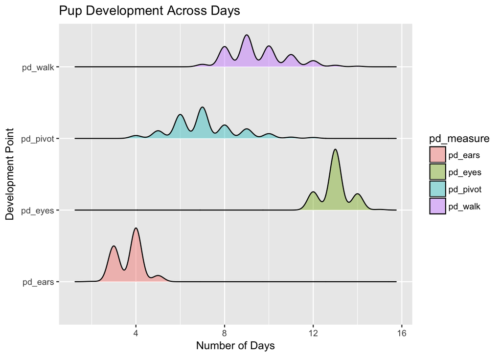

```r
#creating plot
library(ggridges)

#ridge plot to look across day differences in developemnt
pups_plot = pups_data_tidy%>%
  ggplot(aes(x = pd_outcome, y = pd_measure)) + geom_density_ridges(scale = .85, aes(fill = pd_measure), alpha = .4) + labs(title = "Pup Development Across Days",
       x = "Number of Days",
       y = "Development Point")

pups_plot
```

The pups_data dataset contained 313 observations across 6 variables originally. It was then tidied for our purposes in this problem. The developmental points: ears, eyes, pivot, and walk were spread out for us to be able to evaluate the difference in time among the different points. The resulting dataset had 1208 obersvations across 4 variables. We made a ridge plot showing the differences in time among these developmental points. For most points, the number of days seems to vary, but it contained to a certain time frame. It seeems for pd_eyes, the majority of pups develop eyes in the day 12-14 time frame, with very little developing before or after. For the others, this time interval seems to be a little more spread out acorss time, and spread evenly through the litters. For example, a pretty even amount of pups seem to develop at pd_walk in the day 8-12 time frame.